# Ex 2

# Exercise 2. Testing Correlated Character Evolution

**Aim:** Test if character evolution is (un)correlated using AIC.

For this exercise you need to source some precooked functions from the file `SMM_functions.R`; they are used for constructing amalgamated reate matrices. Copy this file from GitHub to you working directory and execute the code below.

```r
# useful functions
source("SMM_functions.R")
```

## 1. Simulate tree.

Let’s make a correlated character where tail color evolution is correlated with tail shape (long, short)

```r
# initialize shape character
char.state<-c("L", "S")
rate.param<-c(0.1, 0.1)
TL<-init_char_matrix(char.state, rate.param, diag.as=0)
diag(TL)<-rate.param*-1
TL
```

```
     L    S
L -0.1  0.1
S  0.1 -0.1
```

```r
# initialize color character
char.state<-c("r", "b")
rate.param<-c(0.1, 0.1)
COL<-init_char_matrix(char.state, rate.param, diag.as=0)
diag(COL)<-rate.param*-1
COL
```

```
     r    b
r -0.1  0.1
b  0.1 -0.1
```

```r
# amalgamate two characters
Q.ind<-comb2matrices(TL, COL, controlling.state=2, name.sep="", diag.as="")
Q.ind
```

```
     Lr   Lb   Sr   Sb
Lr -0.1  0.0  0.1  0.0
Lb  0.0 -0.1  0.0  0.1
Sr  0.1  0.0 -0.2  0.1
Sb  0.0  0.1  0.1 -0.2
```

```r
# make the character correlated
Q.cor <- Q.ind
Q.cor[2,4] <- 0.3
Q.cor[3,4] <- 0.3
diag(Q.cor) <- 0
diag(Q.cor) <- -rowSums(Q.cor)
Q.cor
```

```
     Lr   Lb   Sr   Sb
Lr -0.1  0.0  0.1  0.0
Lb  0.0 -0.3  0.0  0.3
Sr  0.1  0.0 -0.4  0.3
Sb  0.0  0.1  0.1 -0.2
```

## 2. Simulate character evolution on the tree under the correlated model $M_0$.

```r
tree<-pbtree(n=100, scale=200)
sim.h<-sim.history(tree, Q.cor, nsim=1, anc=setNames(c(1, 0, 0, 0), colnames(Q.cor) ) )
```

```
Note - the rate of substitution from i->j should be given by Q[j,i].
Detecting that rows, not columns, of Q sum to zero :
Transposing Q for internal calculations.
Done simulation(s).
```

```
no colors provided. using the following legend:
      Lb       Lr       Sb       Sr
 "black"    "red" "green3"   "blue"
```

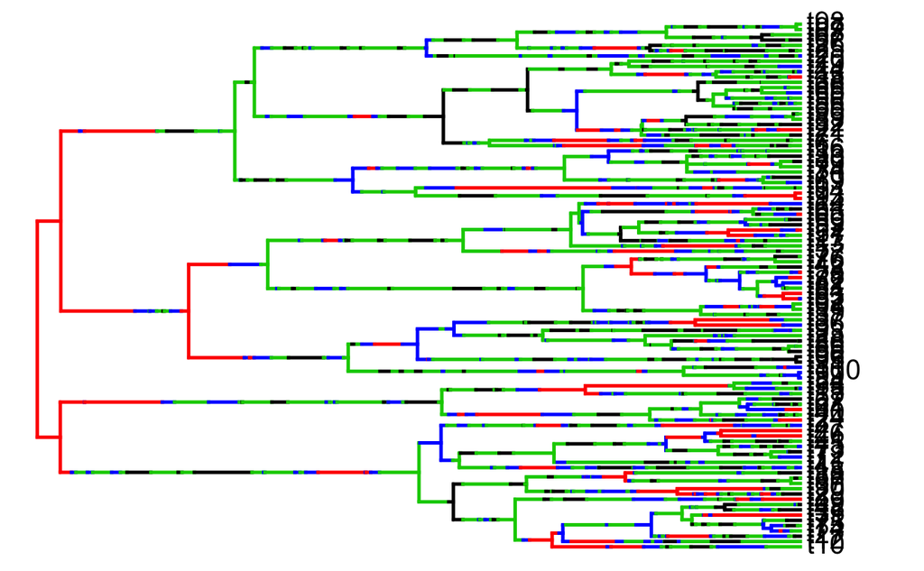

```r
plot(sim.h)
```

## 3. Fit two models to data ($M_0$: correlated and $M_1$: uncorrelated).

Let’s first construct rate matrices that we will use for the ML inference

```r
# matrix template for inference
char.state<-c("T", "C")
rate.param<-c(1, 1)
TL<-init_char_matrix(char.state, rate.param, diag.as=0)

char.state<-c("r", "b")
rate.param<-c(1, 1)
COL<-init_char_matrix(char.state, rate.param, diag.as=0)

# uncorrelated matrix
M.equal<-comb2matrices(TL, COL,  name.sep="", diag.as="", non.rate.as=NA)
M.equal
```

```
   Tr Tb Cr Cb
Tr NA  1  1 NA
Tb  1 NA NA  1
Cr  1 NA NA  1
Cb NA  1  1 NA
```

```r
# correlated matrix
M.corr <- M.equal
M.corr[2,4] <- 2
M.corr[3,4] <- 2
M.corr
```

```
   Tr Tb Cr Cb
Tr NA  1  1 NA
Tb  1 NA NA  2
Cr  1 NA NA  2
Cb NA  1  1 NA
```

### ML Inference

[output not shown]

```r
# uncorrelated matrix
taxa <- cbind(hist$tip.label, sim.h$states)
out.equal <- rayDISC(sim.h, taxa, rate.mat=M.equal, node.states="marginal", model="ARD", root.p="maddfitz")
```

```
State distribution in data:
States: 1   2   3   4
Counts: 24  20  40  16
Initializing...
Finished. Beginning thorough search...
Finished. Inferring ancestral states using marginal reconstruction.
```

```r
# correlated matrix
out.corr <- rayDISC(sim.h, taxa, rate.mat=M.corr, node.states="marginal", model="ARD", root.p="maddfitz")
```

```
State distribution in data:
States: 1   2   3   4
Counts: 24  20  40  16
Initializing...
Finished. Beginning thorough search...
Finished. Inferring ancestral states using marginal reconstruction.
```

```r
out.corr$AIC
```

```
[1] 276.5008
```

## Answer the Questions

1. Which model is suggested by AIC: the uncorrelated or correlated one?
2. What are the differences inn Q between correlated and uncorrelated models?
3. Do you know any real life cases where evolution of discrete traits might be correlated?